# Meiofauna and Macrofauna Biomass-Size Composition

### 2.1.1 Distance based redundancy analysis

Distance-based Redundancy Analysis (dbRDA) was used to model the biomass of log2-size bin in each sample using environmental variables.

#### 2.1.1.1 Full model

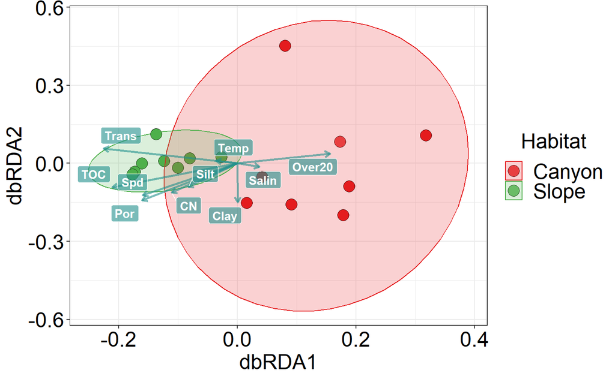

```r
keep <- match(with(fr, paste(Cruise, Station)), with(env, paste(Cruise, Station)))
db <- dbrda(mei_sc^0.25~Spd+over20+CN+transmissometer+TOC+Porosity+Clay+Silt+Salinity+Temperature, distance = "bray", data=es[keep,])
fit <- as.data.frame(db$CCA$biplot)
sc <- min(abs(c(range(db$CCA$u[,1]), range(db$CCA$u[,1]))))
fit <- fit*sc*1.8
fit <- cbind(fit, label=c("Spd", "Over20", "CN", "Trans", "TOC", "Por", "Clay", "Silt", "Salin", "Temp"))

ggplot(data=cbind(as.data.frame(db$CCA$u), env[keep,]), aes(x=dbRDA1, y=dbRDA2))+
  geom_point(size=5, pch=21, colour=gray(0, 0.2), alpha=0.8, aes(fill=Habitat))+
  #geom_point(data=cbind(as.data.frame(db$CCA$u), env[keep,]) %>% subset(Cruise=="OR1_1114"), pch=21, size=4, fill="white", colour="black")+
  stat_ellipse(type="norm", geom = "polygon", alpha = 0.2, aes(colour=Habitat, fill=Habitat))+
  geom_segment(data=fit, aes(x=0, y=0, xend=dbRDA1, yend=dbRDA2), size=1,
               arrow = arrow(length = unit(0.2,"cm")), colour=viridis(3, 0.6)[2])+
  geom_label_repel(data=fit, aes(x=dbRDA1, y=dbRDA2, label=label), fill=viridis(3, 0.6)[2], colour="white", size=4, fontface = "bold")+
  #scale_color_viridis(discrete = TRUE)+
  #scale_fill_viridis(discrete = TRUE)+
  scale_color_manual(values=c("#e41a1c", "#4daf4a"))+
  scale_fill_manual(values=c("#e41a1c", "#4daf4a"))+
  theme_bw() %+replace% large
```

```r
su <- summary(db)
cat("Constrained proportion = ", round(su$constr.chi/su$tot.chi*100, 1), "%", "\n",
    "Unconstrained proportion = ", round(su$unconst.chi/su$tot.chi*100, 1), "%", "\n",
    "dbRDA1 explains", round(su$cont$importance[2, 1]*100,1), "% of fit",
    "and", round(su$cont$importance[2, 1]*100*su$constr.chi/su$tot.chi, 1), "% of total", "\n",
    "dbRDA2 explains", round(su$cont$importance[2, 2]*100,1), "% of fit",
    "and", round(su$cont$importance[2, 2]*100*su$constr.chi/su$tot.chi, 1), "% of total")
```

```
## Constrained proportion =  57.4 %
##  Unconstrained proportion =  42.6 %
##  dbRDA1 explains 33.3 % of fit and 19.1 % of total
##  dbRDA2 explains 14.2 % of fit and 8.2 % of total
```

#### 2.1.1.2 Model selection based on AIC

Subset of environmental variables best explained the biomass-size composition were selected by AIC. The selected variables were projected as vectors on to the same nMDS ordination with the length of vectors indicating their correlations with the nMDS ordination scores and direction of vectors indicating the direction of increasing environmental values.

```r
ordistep(db, permutations=999)
```

```
##
## Start: mei_sc^0.25 ~ Spd + over20 + CN + transmissometer + TOC + Porosity +      Clay + Silt + Salinity + Temperature
##
##                   Df    AIC      F Pr(>F)
## - Salinity         1 65.459 0.8003  0.548
## - transmissometer  1 65.814 1.0773  0.365
## - Clay             1 65.986 1.2126  0.301
## - CN               1 66.555 1.6635  0.180
## - over20           1 66.577 1.6811  0.173
## - TOC              1 66.921 1.9564  0.099 .
## - Temperature      1 67.235 2.2098  0.069 .
## - Silt             1 69.469 4.0610  0.007 **
## - Spd              1 70.138 4.6334  0.002 **
## - Porosity         1 71.233 5.5883  0.001 ***
## ---
## Signif. codes:  0 '***' 0.001 '**' 0.01 '*' 0.05 '.' 0.1 ' ' 1
##
## Step: mei_sc^0.25 ~ Spd + over20 + CN + transmissometer + TOC + Porosity +      Clay + Silt + Temperature
##
##                   Df    AIC      F Pr(>F)
## - transmissometer  1 64.978 1.2085  0.279
## - Clay             1 65.204 1.3917  0.202
## - CN               1 65.542 1.6674  0.162
## - over20           1 65.680 1.7810  0.133
## - TOC              1 65.913 1.9728  0.092 .
## - Temperature      1 66.217 2.2241  0.055 .
## - Spd              1 69.056 4.6576  0.004 **
## - Silt             1 68.630 4.2830  0.002 **
## - Porosity         1 70.120 5.6087  0.001 ***
## ---
## Signif. codes:  0 '***' 0.001 '**' 0.01 '*' 0.05 '.' 0.1 ' ' 1
##
## Step: mei_sc^0.25 ~ Spd + over20 + CN + TOC + Porosity + Clay + Silt +      Temperature
##
##               Df    AIC      F Pr(>F)
## - CN           1 65.404 2.0040  0.095 .
## - TOC          1 66.731 3.1455  0.018 *
## - Temperature  1 66.724 3.1389  0.014 *
## - Spd          1 68.085 4.3446  0.005 **
## - Porosity     1 69.153 5.3153  0.002 **
## - Clay         1 70.381 6.4600  0.001 ***
## - Silt         1 71.937 7.9561  0.001 ***
## - over20       1 73.343 9.3515  0.001 ***
## ---
## Signif. codes:  0 '***' 0.001 '**' 0.01 '*' 0.05 '.' 0.1 ' ' 1
```

```
## Call: dbrda(formula = mei_sc^0.25 ~ Spd + over20 + CN + TOC + Porosity
## + Clay + Silt + Temperature, data = es[keep, ], distance = "bray")
##
##               Inertia Proportion Rank RealDims
## Total          6.3062     1.0000
## Constrained    3.4678     0.5499    8        7
## Unconstrained  2.8384     0.4501   37       19
## Inertia is squared Bray distance
##
## Eigenvalues for constrained axes:
##  dbRDA1  dbRDA2  dbRDA3  dbRDA4  dbRDA5  dbRDA6  dbRDA7 idbRDA1
##  2.0963  0.8815  0.2396  0.1230  0.0826  0.0357  0.0148 -0.0058
##
## Eigenvalues for unconstrained axes:
##   MDS1   MDS2   MDS3   MDS4   MDS5   MDS6   MDS7   MDS8
## 0.8128 0.6292 0.4992 0.3790 0.2444 0.2284 0.1669 0.1348
## (Showing 8 of 37 unconstrained eigenvalues)
```

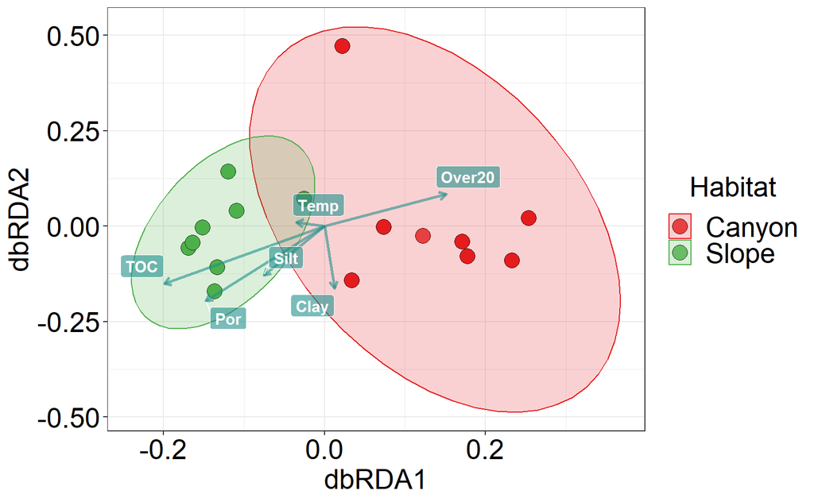

```r
db <- dbrda(formula = mei_sc^0.25 ~ over20 + TOC + Porosity + Clay + Silt + Temperature, data = es[keep, ], distance = "bray")
fit <- as.data.frame(db$CCA$biplot)
sc <- min(abs(c(range(db$CCA$u[,1]), range(db$CCA$u[,1]))))
fit <- fit*sc*1.8
fit <- cbind(fit, label=c("Over20", "TOC", "Por", "Clay", "Silt", "Temp"))

ggplot(data=cbind(as.data.frame(db$CCA$u), env[keep,]), aes(x=dbRDA1, y=dbRDA2))+
  geom_point(size=5, pch=21, colour=gray(0, 0.2), alpha=0.8, aes(fill=Habitat))+
  #geom_point(data=cbind(as.data.frame(db$CCA$u), env[keep,]) %>% subset(Cruise=="OR1_1114"), pch=21, size=4, fill="white", colour="black")+
  stat_ellipse(type="norm", geom = "polygon", alpha = 0.2, aes(colour=Habitat, fill=Habitat))+
  geom_segment(data=fit, aes(x=0, y=0, xend=dbRDA1, yend=dbRDA2), size=1,
               arrow = arrow(length = unit(0.2,"cm")), colour=viridis(3, 0.6)[2])+
  geom_label_repel(data=fit, aes(x=dbRDA1, y=dbRDA2, label=label), fill=viridis(3, 0.6)[2], colour="white", size=4, fontface = "bold")+
  #scale_color_viridis(discrete = TRUE)+
  #scale_fill_viridis(discrete = TRUE)+
  scale_color_manual(values=c("#e41a1c", "#4daf4a"))+
  scale_fill_manual(values=c("#e41a1c", "#4daf4a"))+
  theme_bw() %+replace% large
```

```r
su <- summary(db)
cat("Constrained proportion = ", round(su$constr.chi/su$tot.chi*100, 1), "%", "\n",
    "Unconstrained proportion = ", round(su$unconst.chi/su$tot.chi*100, 1), "%", "\n",
    "dbRDA1 explains", round(su$cont$importance[2, 1]*100,1), "% of fit",
    "and", round(su$cont$importance[2, 1]*100*su$constr.chi/su$tot.chi, 1), "% of total", "\n",
    "dbRDA2 explains", round(su$cont$importance[2, 2]*100,1), "% of fit",
    "and", round(su$cont$importance[2, 2]*100*su$constr.chi/su$tot.chi, 1), "% of total")
```

```
## Constrained proportion =  47.7 %
##  Unconstrained proportion =  52.3 %
##  dbRDA1 explains 31.4 % of fit and 15 % of total
##  dbRDA2 explains 10.9 % of fit and 5.2 % of total
```

### 2.1.2 Correlation between environmental variables and nMDS ordination

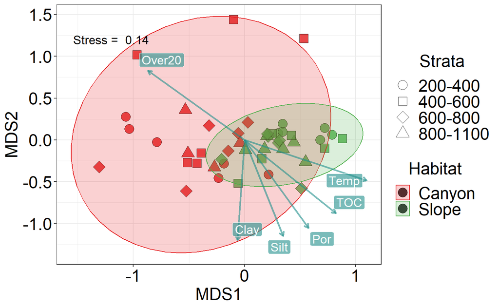

```r
fit <- envfit(mei_md$points, es[keep, c("over20", "TOC", "Porosity", "Clay", "Silt", "Temperature")])
lab <- data.frame(fit$vectors$arrows*1.2)
lab$label <- c("Over20", "TOC", "Por", "Clay", "Silt", "Temp")

(f6b <- ggplot(data=cbind(mei_md$points, env[keep,]), aes(x=MDS1, y=MDS2))+
  geom_point(aes(fill=Habitat, colour=Habitat, shape=Strata), alpha=0.8, size=5, colour=gray(0, 0.2))+
  #geom_point(data=cbind(mei_md$points, enve) %>% subset(Cruise=="OR1_1114"), pch=21, size=2, fill="white", colour="black")+
  stat_ellipse(type="norm", geom = "polygon", alpha = 0.2, aes(colour=Habitat, fill=Habitat))+
  annotate("text", x=-1.2, y=1.2, label=stress, size=5)+
  geom_segment(data=lab, aes(x=0, y=0, xend=MDS1, yend=MDS2), size=1, arrow = arrow(length = unit(0.2,"cm")), colour=viridis(3, 0.6)[2])+
  geom_label_repel(data=lab, aes(label=label), fill=viridis(3, 0.6)[2],
             colour="white", size=5, label.padding = unit(0.2, "lines"))+
  #scale_fill_viridis(discrete = TRUE)+
  #scale_color_viridis(discrete = TRUE)+
  scale_color_manual(values=c("#e41a1c", "#4daf4a"))+
  scale_fill_manual(values=c("#e41a1c", "#4daf4a"))+
  scale_shape_manual(values=21:24)+
  theme_bw() %+replace% large
)
```

These variables are mapped onto the same nMDS plot using their correlations with the ordination axes, showing that the canyon assemblages were characterized by increasing duration of bottom current velocity exceeding 20 cm/s (Over20) and the slope assemblages by increasing total organic carbon contents (TOC).

## 2.2 Per station

```r
mei_sc2 <- acast(mei_s, Cruise+Habitat+Station+Depth~Class, value.var = "Wt", fun.aggregate=mean, na.rm=TRUE)
mei_sc2[is.na(mei_sc2)] <- 0
fr <- strsplit(row.names(mei_sc2), split="_") %>%ldply
fr <- cbind(paste(fr$V1, fr$V2, sep="_"), fr[,-1:-2])
names(fr) <- c("Cruise", "Habitat", "Station", "Depth")
fr$Depth <- as.numeric(fr$Depth)

# Main effect
f <- adonis(mei_sc2~Habitat+Cruise+Depth+Habitat:Depth+Habitat:Cruise+Depth:Cruise, data=fr, method="bray")
kable(f$aov.tab)
```

|  | Df | SumsOfSqs | MeanSqs | F.Model | R2 | Pr(>F) |
| --- | --- | --- | --- | --- | --- | --- |
| Habitat | 1 | 1.0003402 | 1.0003402 | 3.9010034 | 0.2044142 | 0.001 |
| Cruise | 1 | 0.1657209 | 0.1657209 | 0.6462579 | 0.0338642 | 0.742 |
| Depth | 1 | 0.4644913 | 0.4644913 | 1.8113659 | 0.0949163 | 0.096 |
| Habitat:Depth | 1 | 0.3348642 | 0.3348642 | 1.3058623 | 0.0684277 | 0.250 |
| Habitat:Cruise | 1 | 0.2118069 | 0.2118069 | 0.8259785 | 0.0432816 | 0.579 |
| Cruise:Depth | 1 | 0.4085850 | 0.4085850 | 1.5933496 | 0.0834922 | 0.159 |
| Residuals | 9 | 2.3078835 | 0.2564315 | NA | 0.4716038 | NA |
| Total | 15 | 4.8936921 | NA | NA | 1.0000000 | NA |

Only significant habitat effect was detected by PERMANOVA. No statistical effect of cruise and depth.

# 3 Macrofauna size composition

Individual size of macrofauna were binned by log2 transformation of their biomass. The total biomass of each size bin and each sample was than calculated as size composition for further multivariate analysis.